# Step 6.1: Feeding Level Diagnostics

- Show All Code
- Hide All Code
- View Source

Analysis of Feeding Rates After Extended Resource Spectrum

Authors

Tormey E. Reimer

Claude Sonnet 4.5

Published

January 14, 2026

← Previous: Initial Model Setup

# 1 Overview

This document analyzes feeding levels for all species in the Western Antarctic Peninsula mizer model after implementing the extended resource spectrum. The purpose is to diagnose whether species are successfully feeding and identify potential causes of the observed model collapse.

# 2 Load Model Results

```r
library(mizer)
library(tidyverse)
library(here)

# Set model directory
model_dir <- here("..", "Models", "AI-assisted", "Attempt 1")

# Load the initial params
params_initial <- readRDS(file.path(model_dir, "initial_params.rds"))

# Load the steady state simulation
sim <- readRDS(file.path(model_dir, "steady_state_simulation.rds"))

# Load the steady state params
params_steady <- readRDS(file.path(model_dir, "steady_state_params.rds"))

# Load species parameters
species_params <- read_csv(file.path(model_dir, "species_parameters.csv"),
                          show_col_types = FALSE)

# Load resource parameters
resource_params <- readRDS(file.path(model_dir, "resource_params.rds"))
```

# 3 Resource Spectrum Parameters

Let’s first confirm the extended resource spectrum parameters:

```r
cat("Extended Resource Spectrum Parameters:\n")
```

```
Extended Resource Spectrum Parameters:
```

```r
cat("=====================================\n")
cat(sprintf("Size range: %.2e to %.2f g\n",
            resource_params$w_min, resource_params$w_pp_cutoff))
```

```
Size range: 1.00e-10 to 10.00 g
```

```r
cat(sprintf("Kappa: %.2f\n", resource_params$kappa))
```

```
Kappa: 257.37
```

```r
cat(sprintf("Lambda: %.2f\n", resource_params$lambda))
```

```
Lambda: 2.05
```

```r
cat(sprintf("Resource rate: %.4f /day (%.2f /year)\n",
            resource_params$r_pp, resource_params$r_pp_annual))
cat(sprintf("Target biomass: %.0f g/m² (%.0f t/km²)\n",
            resource_params$target_biomass, resource_params$target_biomass))
```

```
Target biomass: 11690 g/m² (11690 t/km²)
```

```r
cat(sprintf("Forcing strategy: %s\n", resource_params$forcing_strategy))
```

```
Forcing strategy: zooplankton_only_phase1
```

# 4 Initial Feeding Levels

Feeding level represents the proportion of maximum consumption rate that a species achieves. Values should typically be between 0.3 and 0.8 for a healthy, stable ecosystem.

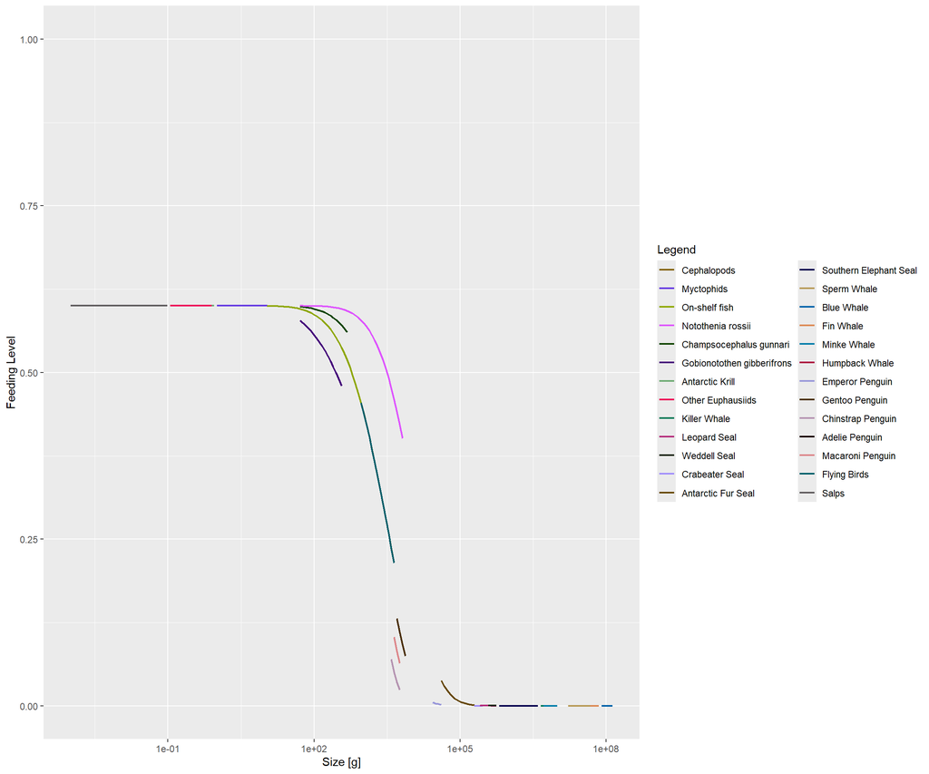

Initial feeding levels by species and size

```r
plotFeedingLevel(params_initial)
```

## 4.1 Initial Feeding Level Statistics

```r
# Calculate feeding levels
feeding_initial <- getFeedingLevel(params_initial)

# Get size-weighted mean feeding level for each species
feeding_stats_initial <- data.frame(
  species = dimnames(feeding_initial)$sp,
  mean_feeding = apply(feeding_initial, 1, mean, na.rm = TRUE),
  min_feeding = apply(feeding_initial, 1, min, na.rm = TRUE),
  max_feeding = apply(feeding_initial, 1, max, na.rm = TRUE),
  category = species_params$category
) %>%
  arrange(mean_feeding)

cat("Initial Feeding Levels by Species:\n")
```

```
Initial Feeding Levels by Species:
```

```r
cat("===================================\n\n")
print(feeding_stats_initial, digits = 3)
```

```
                                              species mean_feeding min_feeding
Salps                                           Salps        0.289    2.78e-10
Other Euphausiids                   Other Euphausiids        0.301    1.43e-05
Antarctic Krill                       Antarctic Krill        0.302    5.59e-04
Adelie Penguin                         Adelie Penguin        0.329    8.69e-12
Chinstrap Penguin                   Chinstrap Penguin        0.329    2.75e-11
Macaroni Penguin                     Macaroni Penguin        0.332    1.23e-10
Gobionotothen gibberifrons Gobionotothen gibberifrons        0.332    2.56e-05
Emperor Penguin                       Emperor Penguin        0.334    4.34e-13
Gentoo Penguin                         Gentoo Penguin        0.334    9.92e-09
Flying Birds                             Flying Birds        0.339    2.42e-15
On-shelf fish                           On-shelf fish        0.339    9.27e-05
Myctophids                                 Myctophids        0.339    1.04e-04
Cephalopods                               Cephalopods        0.339    9.01e-05
Blue Whale                                 Blue Whale        0.345    3.88e-16
Fin Whale                                   Fin Whale        0.345    3.88e-16
Humpback Whale                         Humpback Whale        0.345    3.88e-16
Minke Whale                               Minke Whale        0.347    1.45e-14
Crabeater Seal                         Crabeater Seal        0.347    1.42e-14
Weddell Seal                             Weddell Seal        0.355    6.89e-08
Champsocephalus gunnari       Champsocephalus gunnari        0.355    1.27e-09
Antarctic Fur Seal                 Antarctic Fur Seal        0.361    4.20e-09
Southern Elephant Seal         Southern Elephant Seal        0.371    3.94e-11
Leopard Seal                             Leopard Seal        0.371    7.72e-11
Notothenia rossii                   Notothenia rossii        0.373    3.65e-09
Killer Whale                             Killer Whale        0.384    1.75e-15
Sperm Whale                               Sperm Whale        0.384    1.75e-15
                           max_feeding category
Salps                              0.6    other
Other Euphausiids                  0.6    krill
Antarctic Krill                    0.6    krill
Adelie Penguin                     0.6  penguin
Chinstrap Penguin                  0.6  penguin
Macaroni Penguin                   0.6  penguin
Gobionotothen gibberifrons         0.6     fish
Emperor Penguin                    0.6  penguin
Gentoo Penguin                     0.6  penguin
Flying Birds                       0.6     bird
On-shelf fish                      0.6     fish
Myctophids                         0.6     fish
Cephalopods                        0.6     fish
Blue Whale                         0.6    whale
Fin Whale                          0.6    whale
Humpback Whale                     0.6    whale
Minke Whale                        0.6    whale
Crabeater Seal                     0.6     seal
Weddell Seal                       0.6     seal
Champsocephalus gunnari            0.6     fish
Antarctic Fur Seal                 0.6     seal
Southern Elephant Seal             0.6     seal
Leopard Seal                       0.6     seal
Notothenia rossii                  0.6     fish
Killer Whale                       0.6     seal
Sperm Whale                        0.6    whale
```

```r
cat("\n\nSummary by Category:\n")
```

```
Summary by Category:
```

```r
feeding_by_category <- feeding_stats_initial %>%
  group_by(category) %>%
  summarize(
    n = n(),
    mean_feeding = mean(mean_feeding),
    min_feeding = min(mean_feeding),
    max_feeding = max(mean_feeding),
    .groups = "drop"
  ) %>%
  arrange(mean_feeding)
print(feeding_by_category, digits = 3)
```

```
# A tibble: 7 × 5
  category     n mean_feeding min_feeding max_feeding
  <chr>    <int>        <dbl>       <dbl>       <dbl>
1 other        1        0.289       0.289       0.289
2 krill        2        0.301       0.301       0.301
3 penguin      5        0.332       0.332       0.332
4 bird         1        0.339       0.339       0.339
5 fish         6        0.346       0.346       0.346
6 whale        5        0.353       0.353       0.353
7 seal         6        0.365       0.365       0.365
```

```r
# Identify species with very low feeding
low_feeding <- feeding_stats_initial %>%
  filter(mean_feeding < 0.3)

cat("\n\nSpecies with mean feeding level < 0.3:\n")
```

```
Species with mean feeding level < 0.3:
```

```r
if (nrow(low_feeding) > 0) {
  print(low_feeding, digits = 3)
} else {
  cat("None - all species have adequate feeding levels\n")
}
```

```
      species mean_feeding min_feeding max_feeding category
Salps   Salps        0.289    2.78e-10         0.6    other
```

# 5 Steady State Feeding Levels

Now let’s check feeding levels at the end of the 100-year simulation:

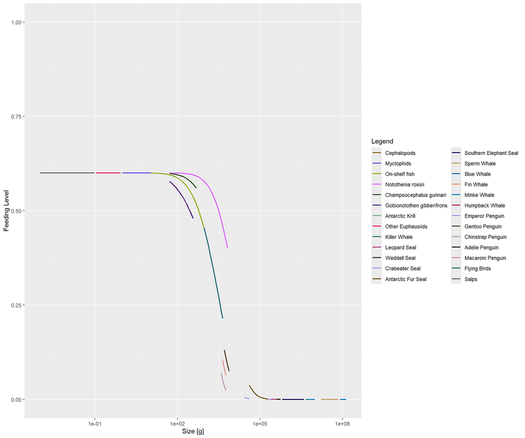

Steady state feeding levels by species and size

```r
plotFeedingLevel(params_steady)
```

## 5.1 Steady State Feeding Level Statistics

```r
# Calculate feeding levels
feeding_steady <- getFeedingLevel(params_steady)

# Get size-weighted mean feeding level for each species
feeding_stats_steady <- data.frame(
  species = dimnames(feeding_steady)$sp,
  mean_feeding = apply(feeding_steady, 1, mean, na.rm = TRUE),
  min_feeding = apply(feeding_steady, 1, min, na.rm = TRUE),
  max_feeding = apply(feeding_steady, 1, max, na.rm = TRUE),
  category = species_params$category
) %>%
  arrange(mean_feeding)

cat("Steady State Feeding Levels by Species:\n")
```

```
Steady State Feeding Levels by Species:
```

```r
cat("========================================\n\n")
print(feeding_stats_steady, digits = 3)
```

```
                                              species mean_feeding min_feeding
Salps                                           Salps        0.289    1.03e-13
Other Euphausiids                   Other Euphausiids        0.301    4.99e-08
Antarctic Krill                       Antarctic Krill        0.301    3.80e-06
Adelie Penguin                         Adelie Penguin        0.329    2.75e-13
Chinstrap Penguin                   Chinstrap Penguin        0.329    9.33e-13
Macaroni Penguin                     Macaroni Penguin        0.332    7.65e-13
Gobionotothen gibberifrons Gobionotothen gibberifrons        0.332    1.63e-07
Emperor Penguin                       Emperor Penguin        0.334    6.05e-16
Gentoo Penguin                         Gentoo Penguin        0.334    2.75e-11
Flying Birds                             Flying Birds        0.339    2.42e-15
Myctophids                                 Myctophids        0.339    6.44e-07
Cephalopods                               Cephalopods        0.339    6.51e-07
On-shelf fish                           On-shelf fish        0.339    7.32e-07
Blue Whale                                 Blue Whale        0.345    0.00e+00
Fin Whale                                   Fin Whale        0.345    0.00e+00
Humpback Whale                         Humpback Whale        0.345    0.00e+00
Minke Whale                               Minke Whale        0.347    1.31e-15
Crabeater Seal                         Crabeater Seal        0.347    1.99e-15
Champsocephalus gunnari       Champsocephalus gunnari        0.355    1.35e-13
Weddell Seal                             Weddell Seal        0.355    1.49e-10
Antarctic Fur Seal                 Antarctic Fur Seal        0.361    5.71e-12
Southern Elephant Seal         Southern Elephant Seal        0.371    9.52e-14
Leopard Seal                             Leopard Seal        0.371    1.95e-13
Notothenia rossii                   Notothenia rossii        0.373    3.94e-11
Killer Whale                             Killer Whale        0.384    1.75e-15
Sperm Whale                               Sperm Whale        0.384    1.75e-15
                           max_feeding category
Salps                              0.6    other
Other Euphausiids                  0.6    krill
Antarctic Krill                    0.6    krill
Adelie Penguin                     0.6  penguin
Chinstrap Penguin                  0.6  penguin
Macaroni Penguin                   0.6  penguin
Gobionotothen gibberifrons         0.6     fish
Emperor Penguin                    0.6  penguin
Gentoo Penguin                     0.6  penguin
Flying Birds                       0.6     bird
Myctophids                         0.6     fish
Cephalopods                        0.6     fish
On-shelf fish                      0.6     fish
Blue Whale                         0.6    whale
Fin Whale                          0.6    whale
Humpback Whale                     0.6    whale
Minke Whale                        0.6    whale
Crabeater Seal                     0.6     seal
Champsocephalus gunnari            0.6     fish
Weddell Seal                       0.6     seal
Antarctic Fur Seal                 0.6     seal
Southern Elephant Seal             0.6     seal
Leopard Seal                       0.6     seal
Notothenia rossii                  0.6     fish
Killer Whale                       0.6     seal
Sperm Whale                        0.6    whale
```

```r
cat("\n\nSummary by Category:\n")
```

```
Summary by Category:
```

```r
feeding_by_category_steady <- feeding_stats_steady %>%
  group_by(category) %>%
  summarize(
    n = n(),
    mean_feeding = mean(mean_feeding, na.rm = TRUE),
    min_feeding = min(mean_feeding, na.rm = TRUE),
    max_feeding = max(mean_feeding, na.rm = TRUE),
    .groups = "drop"
  ) %>%
  arrange(mean_feeding)
print(feeding_by_category_steady, digits = 3)
```

```
# A tibble: 7 × 5
  category     n mean_feeding min_feeding max_feeding
  <chr>    <int>        <dbl>       <dbl>       <dbl>
1 other        1        0.289       0.289       0.289
2 krill        2        0.301       0.301       0.301
3 penguin      5        0.332       0.332       0.332
4 bird         1        0.339       0.339       0.339
5 fish         6        0.346       0.346       0.346
6 whale        5        0.353       0.353       0.353
7 seal         6        0.365       0.365       0.365
```

# 6 Comparison: Initial vs Steady State

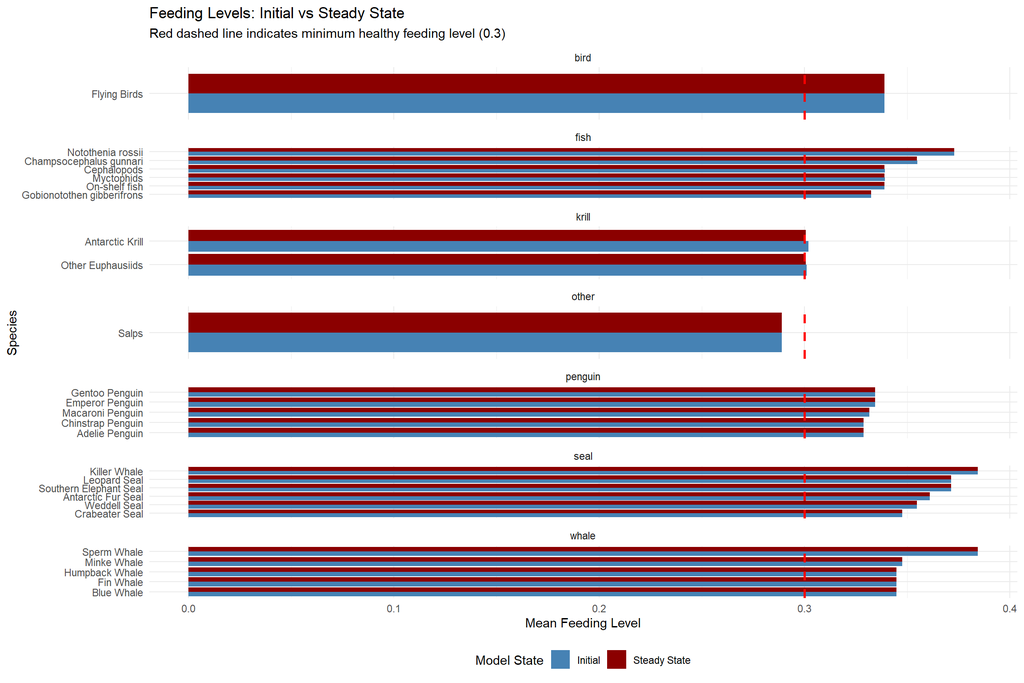

Comparison of mean feeding levels: Initial vs Steady State

```r
comparison <- feeding_stats_initial %>%
  select(species, category, initial_feeding = mean_feeding) %>%
  left_join(
    feeding_stats_steady %>% select(species, steady_feeding = mean_feeding),
    by = "species"
  ) %>%
  pivot_longer(cols = c(initial_feeding, steady_feeding),
               names_to = "state",
               values_to = "feeding_level")

ggplot(comparison, aes(x = reorder(species, feeding_level),
                       y = feeding_level,
                       fill = state)) +
  geom_col(position = "dodge") +
  geom_hline(yintercept = 0.3, linetype = "dashed", color = "red", linewidth = 1) +
  coord_flip() +
  scale_fill_manual(values = c("initial_feeding" = "steelblue",
                                "steady_feeding" = "darkred"),
                    labels = c("Initial", "Steady State")) +
  facet_wrap(~category, scales = "free_y", ncol = 1) +
  labs(
    title = "Feeding Levels: Initial vs Steady State",
    subtitle = "Red dashed line indicates minimum healthy feeding level (0.3)",
    x = "Species",
    y = "Mean Feeding Level",
    fill = "Model State"
  ) +
  theme_minimal() +
  theme(legend.position = "bottom")
```

# 7 Resource Availability Check

Let’s check if resources are actually available to consumers:

```r
# Get resource spectrum
resource_n <- params_initial@initial_n_pp
resource_w <- params_initial@w_full[1:length(resource_n)]

# Calculate resource biomass by size
resource_biomass_by_size <- resource_n * resource_w * params_initial@dw_full[1:length(resource_n)]
total_resource_biomass <- sum(resource_biomass_by_size)

cat("Resource Spectrum Analysis:\n")
```

```
Resource Spectrum Analysis:
```

```r
cat("===========================\n")
cat(sprintf("Total resource biomass: %.2f t/km²\n", total_resource_biomass))
```

```
Total resource biomass: 12631.96 t/km²
```

```r
cat(sprintf("Target resource biomass: %.2f t/km²\n", resource_params$target_biomass))
```

```
Target resource biomass: 11690.00 t/km²
```

```r
cat(sprintf("Achievement: %.1f%%\n", 100 * total_resource_biomass / resource_params$target_biomass))
```

```
Achievement: 108.1%
```

```r
# Check resource biomass in size ranges relevant to consumers
cat("\nResource biomass by size range:\n")
```

```
Resource biomass by size range:
```

```r
size_ranges <- list(
  "1e-10 to 1e-6 g (phyto-sized)" = c(1e-10, 1e-6),
  "1e-6 to 0.01 g (small zoo)" = c(1e-6, 0.01),
  "0.01 to 1 g (medium zoo)" = c(0.01, 1),
  "1 to 10 g (large zoo/particles)" = c(1, 10)
)

for (range_name in names(size_ranges)) {
  range_vals <- size_ranges[[range_name]]
  in_range <- resource_w >= range_vals[1] & resource_w <= range_vals[2]
  biomass_in_range <- sum(resource_biomass_by_size[in_range])
  cat(sprintf("  %-35s: %8.2f t/km²\n", range_name, biomass_in_range))
}
```

```
  1e-10 to 1e-6 g (phyto-sized)      :  6467.98 t/km²
  1e-6 to 0.01 g (small zoo)         :  4020.85 t/km²
  0.01 to 1 g (medium zoo)           :  1417.03 t/km²
  1 to 10 g (large zoo/particles)    :   611.85 t/km²
```

# 8 Encounter Rates

Let’s check encounter rates for key species to see if they can actually find food:

```r
# Get encounter rates for initial state
encounter_initial <- getEncounter(params_initial)

# Calculate mean encounter rate by species
encounter_stats <- data.frame(
  species = dimnames(encounter_initial)$sp,
  mean_encounter = apply(encounter_initial, 1, mean, na.rm = TRUE),
  category = species_params$category
) %>%
  arrange(mean_encounter)

cat("Mean Encounter Rates by Species (Initial State):\n")
```

```
Mean Encounter Rates by Species (Initial State):
```

```r
cat("================================================\n\n")
print(encounter_stats, digits = 3)
```

```
                                              species mean_encounter category
Salps                                           Salps       1.55e-01    other
Other Euphausiids                   Other Euphausiids       1.43e+01    krill
Antarctic Krill                       Antarctic Krill       4.83e+01    krill
Myctophids                                 Myctophids       3.56e+03     fish
Gobionotothen gibberifrons Gobionotothen gibberifrons       3.75e+04     fish
On-shelf fish                           On-shelf fish       6.83e+04     fish
Champsocephalus gunnari       Champsocephalus gunnari       1.41e+05     fish
Flying Birds                             Flying Birds       1.01e+06     bird
Notothenia rossii                   Notothenia rossii       1.45e+06     fish
Macaroni Penguin                     Macaroni Penguin       3.59e+06  penguin
Chinstrap Penguin                   Chinstrap Penguin       4.96e+06  penguin
Cephalopods                               Cephalopods       7.74e+06     fish
Gentoo Penguin                         Gentoo Penguin       1.01e+07  penguin
Adelie Penguin                         Adelie Penguin       1.19e+07  penguin
Emperor Penguin                       Emperor Penguin       6.85e+07  penguin
Antarctic Fur Seal                 Antarctic Fur Seal       2.00e+08     seal
Crabeater Seal                         Crabeater Seal       5.17e+08     seal
Weddell Seal                             Weddell Seal       1.13e+09     seal
Leopard Seal                             Leopard Seal       3.89e+09     seal
Southern Elephant Seal         Southern Elephant Seal       1.06e+10     seal
Killer Whale                             Killer Whale       1.32e+10     seal
Minke Whale                               Minke Whale       3.61e+10    whale
Humpback Whale                         Humpback Whale       8.55e+10    whale
Fin Whale                                   Fin Whale       1.73e+11    whale
Blue Whale                                 Blue Whale       4.09e+11    whale
Sperm Whale                               Sperm Whale       1.16e+12    whale
```

```r
# Species with very low encounter rates
low_encounter <- encounter_stats %>%
  filter(mean_encounter < 1e-10)

cat("\n\nSpecies with very low encounter rates:\n")
```

```
Species with very low encounter rates:
```

```r
if (nrow(low_encounter) > 0) {
  print(low_encounter, digits = 3)
} else {
  cat("None - all species have adequate encounter rates\n")
}
```

```
None - all species have adequate encounter rates
```

# 9 Predation Mortality

Check if predation mortality is causing issues:

```r
# Get predation mortality
pred_mort <- getPredMort(params_initial)

# Calculate mean predation mortality by species
if (length(dim(pred_mort)) == 2 && nrow(pred_mort) > 0) {
  pred_mort_stats <- data.frame(
    species = species_params$species,
    mean_pred_mort = apply(pred_mort, 1, mean, na.rm = TRUE),
    max_pred_mort = apply(pred_mort, 1, max, na.rm = TRUE),
    z0 = species_params$z0
  ) %>%
    mutate(
      total_mortality = mean_pred_mort + z0,
      pred_proportion = mean_pred_mort / total_mortality
    ) %>%
    arrange(desc(total_mortality))

  cat("Mortality Analysis by Species:\n")
  cat("==============================\n\n")
  print(pred_mort_stats, digits = 3)
} else {
  cat("Predation mortality data not available or has unexpected structure\n")
  cat("Dimensions:", paste(dim(pred_mort), collapse = " x "), "\n")
}
```

```
Mortality Analysis by Species:
==============================

                                              species mean_pred_mort
Killer Whale                             Killer Whale       7.58e+01
Sperm Whale                               Sperm Whale       1.09e+01
Southern Elephant Seal         Southern Elephant Seal       7.75e+00
Flying Birds                             Flying Birds       5.93e+00
Emperor Penguin                       Emperor Penguin       1.39e+00
Weddell Seal                             Weddell Seal       1.20e+00
Leopard Seal                             Leopard Seal       1.03e+00
Crabeater Seal                         Crabeater Seal       9.96e-01
Cephalopods                               Cephalopods       1.69e-02
Salps                                           Salps       1.76e-05
On-shelf fish                           On-shelf fish       7.16e-01
Humpback Whale                         Humpback Whale       7.95e-01
Antarctic Fur Seal                 Antarctic Fur Seal       7.63e-01
Other Euphausiids                   Other Euphausiids       0.00e+00
Myctophids                                 Myctophids       1.43e-02
Gobionotothen gibberifrons Gobionotothen gibberifrons       1.31e-01
Antarctic Krill                       Antarctic Krill       0.00e+00
Macaroni Penguin                     Macaroni Penguin       1.78e-01
Champsocephalus gunnari       Champsocephalus gunnari       1.83e-02
Gentoo Penguin                         Gentoo Penguin       4.21e-02
Notothenia rossii                   Notothenia rossii       1.81e-02
Chinstrap Penguin                   Chinstrap Penguin       2.31e-02
Fin Whale                                   Fin Whale       2.01e-02
Minke Whale                               Minke Whale       1.93e-02
Adelie Penguin                         Adelie Penguin       1.79e-02
Blue Whale                                 Blue Whale       1.64e-02
                           max_pred_mort     z0 total_mortality pred_proportion
Killer Whale                    6.19e+02 0.0500         75.8699        9.99e-01
Sperm Whale                     6.65e+01 0.0870         11.0112        9.92e-01
Southern Elephant Seal          4.71e+01 0.0630          7.8117        9.92e-01
Flying Birds                    3.61e+01 0.0500          5.9844        9.92e-01
Emperor Penguin                 8.19e+00 0.0583          1.4508        9.60e-01
Weddell Seal                    6.90e+00 0.0500          1.2463        9.60e-01
Leopard Seal                    6.16e+00 0.0810          1.1077        9.27e-01
Crabeater Seal                  5.93e+00 0.0500          1.0463        9.52e-01
Cephalopods                     7.20e-02 0.9450          0.9619        1.76e-02
Salps                           1.06e-04 0.9000          0.9000        1.96e-05
On-shelf fish                   4.30e+00 0.1380          0.8538        8.38e-01
Humpback Whale                  4.73e+00 0.0500          0.8449        9.41e-01
Antarctic Fur Seal              4.45e+00 0.0510          0.8142        9.37e-01
Other Euphausiids               0.00e+00 0.4500          0.4500        0.00e+00
Myctophids                      8.63e-02 0.3300          0.3443        4.16e-02
Gobionotothen gibberifrons      7.82e-01 0.1380          0.2686        4.86e-01
Antarctic Krill                 0.00e+00 0.2400          0.2400        0.00e+00
Macaroni Penguin                9.05e-01 0.0500          0.2275        7.80e-01
Champsocephalus gunnari         1.10e-01 0.1440          0.1623        1.13e-01
Gentoo Penguin                  1.55e-01 0.0660          0.1081        3.90e-01
Notothenia rossii               1.06e-01 0.0870          0.1051        1.72e-01
Chinstrap Penguin               1.05e-01 0.0660          0.0891        2.59e-01
Fin Whale                       9.85e-02 0.0500          0.0701        2.87e-01
Minke Whale                     1.01e-01 0.0500          0.0693        2.79e-01
Adelie Penguin                  1.03e-01 0.0500          0.0679        2.63e-01
Blue Whale                      9.87e-02 0.0500          0.0664        2.47e-01
```

# 10 Growth Rates

Check if species can grow properly:

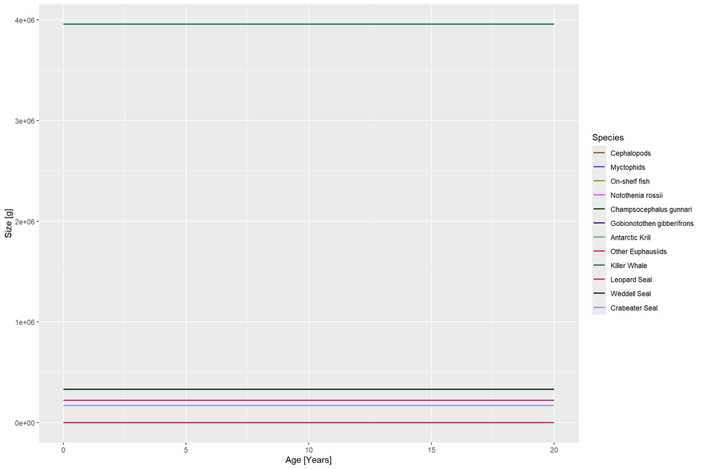

Growth curves for selected species

```r
# Plot growth curves for subset of species
plotGrowthCurves(params_initial,
                 species = species_params$species[1:min(12, nrow(species_params))])
```

# 11 Critical Size Classes

Check if smallest size classes have adequate resources:

```r
# For each species, check feeding level at recruitment size (w_min)
critical_feeding <- data.frame(
  species = species_params$species,
  w_min = species_params$w_min,
  category = species_params$category
)

# Get feeding level at w_min for each species
for (i in 1:nrow(critical_feeding)) {
  sp <- critical_feeding$species[i]
  w_min <- critical_feeding$w_min[i]

  # Find closest size bin
  sp_idx <- which(dimnames(feeding_initial)$sp == sp)
  w_idx <- which.min(abs(params_initial@w - w_min))

  critical_feeding$feeding_at_wmin[i] <- feeding_initial[sp_idx, w_idx]
}

critical_feeding <- critical_feeding %>%
  arrange(feeding_at_wmin)

cat("Feeding Level at Recruitment Size (w_min):\n")
```

```
Feeding Level at Recruitment Size (w_min):
```

```r
cat("==========================================\n\n")
print(critical_feeding, digits = 3)
```

```
                      species   w_min category feeding_at_wmin
1                 Minke Whale 5.0e+06    whale        7.17e-14
2                 Sperm Whale 1.5e+07    whale        3.51e-13
3              Humpback Whale 2.5e+07    whale        4.60e-12
4                   Fin Whale 4.0e+07    whale        8.00e-11
5                  Blue Whale 8.0e+07    whale        1.59e-09
6                Killer Whale 4.0e+06     seal        2.32e-09
7              Crabeater Seal 1.8e+05     seal        8.25e-06
8      Southern Elephant Seal 6.0e+05     seal        5.37e-05
9                Weddell Seal 3.5e+05     seal        6.65e-04
10               Leopard Seal 2.5e+05     seal        1.00e-03
11            Emperor Penguin 2.5e+04  penguin        7.20e-03
12         Antarctic Fur Seal 4.0e+04     seal        3.82e-02
13          Chinstrap Penguin 3.5e+03  penguin        9.45e-02
14             Adelie Penguin 3.5e+03  penguin        9.45e-02
15           Macaroni Penguin 4.0e+03  penguin        1.28e-01
16             Gentoo Penguin 5.0e+03  penguin        1.31e-01
17               Flying Birds 5.0e+02     bird        5.18e-01
18 Gobionotothen gibberifrons 5.0e+01     fish        5.78e-01
19                Cephalopods 1.0e+02     fish        5.87e-01
20    Champsocephalus gunnari 5.0e+01     fish        5.99e-01
21          Notothenia rossii 5.0e+01     fish        6.00e-01
22                      Salps 1.0e-03    other        6.00e-01
23                 Myctophids 1.0e+00     fish        6.00e-01
24          Other Euphausiids 1.0e-01    krill        6.00e-01
25              On-shelf fish 1.0e+01     fish        6.00e-01
26            Antarctic Krill 1.0e-01    krill        6.00e-01
```

```r
cat("\n\nSpecies with feeding < 0.3 at recruitment:\n")
```

```
Species with feeding < 0.3 at recruitment:
```

```r
low_recruitment_feeding <- critical_feeding %>%
  filter(feeding_at_wmin < 0.3)
if (nrow(low_recruitment_feeding) > 0) {
  print(low_recruitment_feeding, digits = 3)
} else {
  cat("None - all species have adequate feeding at recruitment size\n")
}
```

```
                  species   w_min category feeding_at_wmin
1             Minke Whale 5.0e+06    whale        7.17e-14
2             Sperm Whale 1.5e+07    whale        3.51e-13
3          Humpback Whale 2.5e+07    whale        4.60e-12
4               Fin Whale 4.0e+07    whale        8.00e-11
5              Blue Whale 8.0e+07    whale        1.59e-09
6            Killer Whale 4.0e+06     seal        2.32e-09
7          Crabeater Seal 1.8e+05     seal        8.25e-06
8  Southern Elephant Seal 6.0e+05     seal        5.37e-05
9            Weddell Seal 3.5e+05     seal        6.65e-04
10           Leopard Seal 2.5e+05     seal        1.00e-03
11        Emperor Penguin 2.5e+04  penguin        7.20e-03
12     Antarctic Fur Seal 4.0e+04     seal        3.82e-02
13      Chinstrap Penguin 3.5e+03  penguin        9.45e-02
14         Adelie Penguin 3.5e+03  penguin        9.45e-02
15       Macaroni Penguin 4.0e+03  penguin        1.28e-01
16         Gentoo Penguin 5.0e+03  penguin        1.31e-01
```

# 12 Diagnosis Summary

```r
cat("\n")
```

```r
cat("=" , rep("=", 60), "\n", sep = "")
cat("FEEDING LEVEL DIAGNOSTIC SUMMARY\n")
```

```
FEEDING LEVEL DIAGNOSTIC SUMMARY
```

```r
cat("=" , rep("=", 60), "\n\n", sep = "")
cat("1. RESOURCE AVAILABILITY:\n")
```

```
1. RESOURCE AVAILABILITY:
```

```r
cat(sprintf("   - Actual resource biomass: %.2f t/km²\n", total_resource_biomass))
```

```
   - Actual resource biomass: 12631.96 t/km²
```

```r
cat(sprintf("   - Target resource biomass: %.2f t/km²\n", resource_params$target_biomass))
```

```
   - Target resource biomass: 11690.00 t/km²
```

```r
cat(sprintf("   - Achievement: %.1f%%\n\n", 100 * total_resource_biomass / resource_params$target_biomass))
```

```
   - Achievement: 108.1%
```

```r
cat("2. INITIAL FEEDING LEVELS:\n")
```

```
2. INITIAL FEEDING LEVELS:
```

```r
cat(sprintf("   - Species with mean feeding < 0.3: %d/%d\n",
            nrow(low_feeding), nrow(species_params)))
```

```
   - Species with mean feeding < 0.3: 1/26
```

```r
if (nrow(low_feeding) > 0) {
  cat("   - Affected species:", paste(low_feeding$species, collapse = ", "), "\n")
}
```

```
   - Affected species: Salps
```

```r
cat("\n")
```

```r
cat("3. ENCOUNTER RATES:\n")
```

```
3. ENCOUNTER RATES:
```

```r
cat(sprintf("   - Species with very low encounter: %d/%d\n",
            nrow(low_encounter), nrow(species_params)))
```

```
   - Species with very low encounter: 0/26
```

```r
if (nrow(low_encounter) > 0) {
  cat("   - Affected species:", paste(low_encounter$species, collapse = ", "), "\n")
}
cat("\n")
```

```r
cat("4. RECRUITMENT FEEDING:\n")
```

```
4. RECRUITMENT FEEDING:
```

```r
cat(sprintf("   - Species with feeding < 0.3 at w_min: %d/%d\n",
            nrow(low_recruitment_feeding), nrow(species_params)))
```

```
   - Species with feeding < 0.3 at w_min: 16/26
```

```r
if (nrow(low_recruitment_feeding) > 0) {
  cat("   - Affected species:", paste(low_recruitment_feeding$species, collapse = ", "), "\n")
}
```

```
   - Affected species: Minke Whale, Sperm Whale, Humpback Whale, Fin Whale, Blue Whale, Killer Whale, Crabeater Seal, Southern Elephant Seal, Weddell Seal, Leopard Seal, Emperor Penguin, Antarctic Fur Seal, Chinstrap Penguin, Adelie Penguin, Macaroni Penguin, Gentoo Penguin
```

```r
cat("\n")
```

```r
cat("=" , rep("=", 60), "\n", sep = "")
```

# 13 Key Findings

Based on the analysis above:

1. **Resource Biomass**: Check if actual resource biomass matches the target
2. **Feeding Levels**: Identify species with critically low feeding levels (< 0.3)
3. **Size-Specific Issues**: Determine if feeding problems are concentrated at specific sizes
4. **Category Patterns**: Look for systematic issues by taxonomic group

# 14 Recommendations

If feeding levels are low, potential solutions include:

1. **Increase resource biomass further**: Adjust kappa in `02_resource_spectrum.R` to target 10,000-20,000 t/km²
2. **Adjust feeding parameters**: Modify h (max intake), beta (PPMR), or sigma (selectivity) for affected species
3. **Check size ranges**: Ensure w_min values allow species to access appropriate resource sizes
4. **Verify interaction matrix**: Ensure species can feed on available prey
5. **Adjust resource regeneration**: Increase r_pp if resources are being depleted too quickly

Next: Further Calibration →